# gsod: Utilities for exploring NOAA GSOD weather data

DataBrew

2017-12-13

`gsod`, the weather package of [DataBrew](http://databrew.cc), is an effort to streamline the way that researchers and data scientists interact with and utilize weather data.

## Objectives

The objectives of `gsod` package are simple:

1. Make accessing historical weather data easy.
2. Make accessing historical weather data fast.

## Installation

To use the `gsod` package, you’ll first need to install it. With a good internet connection, run the following from within R.

```r
if(!require(devtools)) install.packages("devtools")
install_github('databrew/gsod')
```

Once you’ve installed the package, you can use its functionality in any R script by simply including the following line:

```r
library(gsod)
```

## Basic use

Let’s settle the debate once and for all: which has better weather, the Dutch capital of Amsterdam or the Catalan capital of Barcelona.

```r
# Get weather for 2012-2016
library(gsod)
weather <- bind_rows(gsod2012,
                      gsod2013,
                      gsod2014,
                      gsod2015,
                      gsod2016)
```

Now we’ll find the nearest weather stations to our locations of interest through the `gsod` package’s `find_nearest_station` function:

```r
# Get the station ids
ids <- bind_rows(find_nearest_station('Amsterdam, Netherlands'),
                 find_nearest_station('Barcelona, Catalonia'))
ids
```

```
         stnid   lon    lat       km  stn_name
1 062400-99999 4.764 52.309 11.65975  SCHIPHOL
2 081810-99999 2.078 41.297 13.80614 BARCELONA
```

Next, we’ll plot our weather stations on a world map:

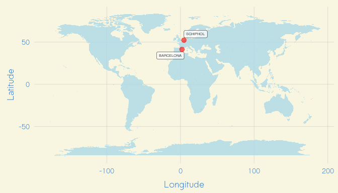

```r
library(rworldmap)
library(ggplot2)
library(ggrepel)
library(databrew)
world <- map_data(map="world")

g <-
  ggplot() +
  theme_databrew() +
  geom_map(data=world,
           map=world,
           aes(map_id=region, x=long, y=lat),
           fill = 'lightblue',
           alpha = 0.8) +
  geom_point(data = ids,
             aes(x = lon,
                 y = lat),
             alpha = 0.6,
             size = 3,
             color = 'red') +
  labs(x = 'Longitude',
       y = 'Latitude') +
  theme(legend.position = 'bottom') +
  geom_label_repel(data = ids,
             aes(x = lon,
                 y = lat,
                 label = stn_name),
             alpha = 0.7,
             size = 2)
g
```

To start, we’ll have a look at the daily high and low temperatures.

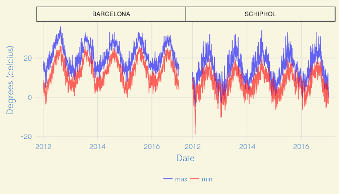

```r
# Get weather for only our two stations
weather <- weather %>%
  filter(stnid %in% ids$stnid)
# Make long tidy data for plotting temperatures
long <- weather %>%
  dplyr::select(date, max, min, stn_name) %>%
  gather(key, value, max:min)
# Compare temperature
g <- ggplot(data = long,
       aes(x = date,
           y = value,
           color = key)) +
  geom_line(alpha = 0.6) +
  facet_wrap(~stn_name) +
  theme(legend.position = 'bottom') +
  scale_color_manual(name = '',
                     values = c('blue', 'red')) +
  theme_databrew() +
  labs(x = 'Date',
       y = 'Degrees (celcius)')
g
```

For many, rainfall matters more than temperature. Let’s have a look at the percentage of days per month which have any precipitation:

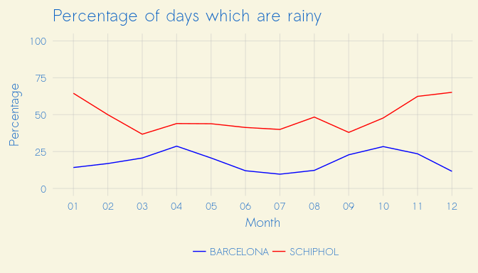

```r
rain <- weather %>%
  mutate(month = format(date, '%m')) %>%
  group_by(month, stn_name) %>%
  summarise(rainy = length(which(prcp > 0)),
            days = n()) %>%
  ungroup %>%
  mutate(p = rainy / days * 100)

ggplot(data = rain,
       aes(x = month,
           y = p,
           color = stn_name,
           group = stn_name)) +
  geom_line() +
  theme_databrew() +
  scale_color_manual(name = '',
                     values = c('blue', 'red')) +
  labs(x = 'Month',
       y = 'Percentage',
       title = 'Percentage of days which are rainy') +
  ylim(0,100)
```

## Conclusion

Amsterdam is great if you like the cold and the rain.

## Details

Head over to the [gsod package page](https://github.com/databrew/gsod).